# CDS 101 – Final Project Report

Werner Wyss - Kanita Haque - Hussein Hamdan

December 05, 2025

# 1 1. Problem Definition

The main question of this project is: Which factors help predict the revenue of a video game? Using the Gaming Industry Trends dataset, we investigate how platform, genre, release year, and other features relate to a game’s financial performance.

This question is interesting because the gaming industry continues to grow, and understanding the features associated with higher revenue can help studios, marketers, and developers make informed decisions. Predictive insights can also help identify which types of games tend to perform well in the market.

Key assumptions include:

- The dataset is accurate and represents industry trends fairly.
- Revenue is influenced by the variables included (platform, genre, release year, etc.).
- Linear modeling is appropriate for exploring these relationships.

# 2 2. Data Acquisition & Description

The dataset is called Gaming Industry Trends and the source for the dataset is Kaggle. We obtained the dataset through the download link on the Kaggle website. The main features would include game title, genre, platform, release year, and revenue, along with possible additional fields describing popularity or rating. The approximate number of rows and columns would be 1000 rows and 11 columns. Some biases to take into consideration would be sampling bias. The dataset would subject to sampling bias due to the limited amount of data given (only 1000 rows). This constraint can exclude large portions of the gaming industry, particularly small studios, niche genres, and emerging platforms.

As a result, the observed trends may reflect more mainstream titles.

# 3 3. Data Cleaning & Preprocessing

The analysis required us to perform data cleaning operations which verified the accuracy and usability of all information in the dataset. The first step involved changing multiple column names because their original names included periods which made them hard to understand. The new names improved the dataset’s readability. The analysis required us to eliminate all entries containing missing essential data points including revenue and genre and platform and release year. The games require these essential variables to perform analysis. The analysis excluded all entries containing invalid data points because real-world data requires positive values for players and revenue. The process involved transforming multiple columns into their appropriate data formats. The analysis required us to convert Genre and Platform into factor variables because they represent categories and Release_Year into an integer data type. The dataset became ready for advanced analysis after we finished all necessary cleaning operations which ensured data consistency and accuracy. The cleaning process protects our analysis from future errors which results in better reliability for our visualizations and models.

```r
library(dplyr)

# Read in the raw CSV
gaming_raw <- read.csv("gaming_industry_trends.csv")

# Rename messy column names with periods to cleaner names with dashes
gaming_raw <- gaming_raw %>%
  rename(
    Game_Title              = Game.Title,
    Release_Year            = Release.Year,
    Revenue_Millions        = Revenue..Millions...,
    Players_Millions        = Players..Millions.,
    Peak_Concurrent_Players = Peak.Concurrent.Players,
    Metacritic_Score        = Metacritic.Score,
    Esports_Popularity      = Esports.Popularity,
    Trending_Status         = Trending.Status
  )

# Drop any possible rows with missing key values
gaming_clean <- gaming_raw %>%
  filter(
    !is.na(Revenue_Millions),
    !is.na(Genre),
    !is.na(Platform),
    !is.na(Release_Year)
  ) %>%
# Remove any possible invalid numeric values
 filter(
    Revenue_Millions > 0,
    Players_Millions >= 0,
    Peak_Concurrent_Players >= 0,
    Metacritic_Score >= 0,
    Metacritic_Score <= 100
  ) %>%
# Convert variables to appropriate types
 mutate(
    Genre                        = as.factor(Genre),
    Platform                     = as.factor(Platform),
    Esports_Popularity           = as.factor(Esports_Popularity),
    Trending_Status              = as.factor(Trending_Status),
    Release_Year                 = as.integer(Release_Year)
  )

# Final check of the cleaned dataset
summary(gaming_clean)
```

```
##   Game_Title             Genre                Platform    Release_Year
##  Length:1000        Action  :122   Cross-Platform :168   Min.   :2000
##  Class :character   Sports  :116   Mobile         :158   1st Qu.:2006
##  Mode  :character   Strategy:116   Nintendo Switch:158   Median :2012
##                     Fighting:103   PC             :174   Mean   :2012
##                     Shooter :100   PlayStation    :175   3rd Qu.:2018
##                     Horror  : 96   Xbox           :167   Max.   :2024
##                     (Other) :347
##   Developer         Revenue_Millions  Players_Millions Peak_Concurrent_Players
##  Length:1000        Min.   :  11.43   Min.   :  0.53   Min.   : 0.11
##  Class :character   1st Qu.:1276.19   1st Qu.: 52.01   1st Qu.:12.97
##  Mode  :character   Median :2476.13   Median :107.04   Median :26.41
##                     Mean   :2483.02   Mean   :103.50   Mean   :31.60
##                     3rd Qu.:3677.80   3rd Qu.:155.63   3rd Qu.:46.02
##                     Max.   :4999.79   Max.   :199.98   Max.   :96.62
##
##  Metacritic_Score Esports_Popularity  Trending_Status
##  Min.   : 50.00   No :493            Declining:326
##  1st Qu.: 62.00   Yes:507            Rising   :335
##  Median : 76.00                      Stable   :339
##  Mean   : 74.99
##  3rd Qu.: 87.00
##  Max.   :100.00
##
```

# 4 4. Exploratory Data Analysis (EDA)

```r
library(ggplot2)

summary(gaming_clean[, c("Revenue_Millions",
                         "Players_Millions",
                         "Peak_Concurrent_Players",
                         "Metacritic_Score",
                         "Release_Year")]
        )
```

```
##  Revenue_Millions  Players_Millions Peak_Concurrent_Players Metacritic_Score
##  Min.   :  11.43   Min.   :  0.53   Min.   : 0.11           Min.   : 50.00
##  1st Qu.:1276.19   1st Qu.: 52.01   1st Qu.:12.97           1st Qu.: 62.00
##  Median :2476.13   Median :107.04   Median :26.41           Median : 76.00
##  Mean   :2483.02   Mean   :103.50   Mean   :31.60           Mean   : 74.99
##  3rd Qu.:3677.80   3rd Qu.:155.63   3rd Qu.:46.02           3rd Qu.: 87.00
##  Max.   :4999.79   Max.   :199.98   Max.   :96.62           Max.   :100.00
##   Release_Year
##  Min.   :2000
##  1st Qu.:2006
##  Median :2012
##  Mean   :2012
##  3rd Qu.:2018
##  Max.   :2024
```

```r
# Frequency tables for main categorical variables
table(gaming_clean$Platform)
```

```
##
##  Cross-Platform          Mobile Nintendo Switch              PC     PlayStation
##             168             158             158             174             175
##            Xbox
##             167
```

```r
table(gaming_clean$Genre)
```

```
##
##     Action  Adventure   Fighting     Horror     Racing        RPG    Shooter
##        122         87        103         96         95         78        100
## Simulation     Sports   Strategy
##         87        116        116
```

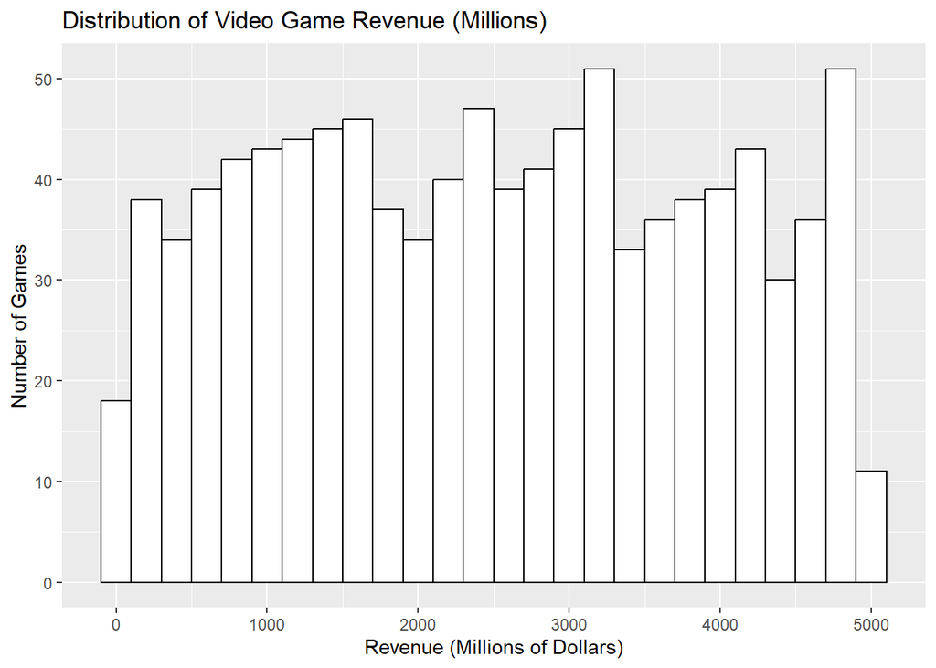

```r
# Histogram of game revenue (in millions)
ggplot(gaming_clean, aes(x = Revenue_Millions)) +
  geom_histogram(binwidth = 200, color = "black", fill = "white") +
  labs(
    title = "Distribution of Video Game Revenue (Millions)",
    x = "Revenue (Millions of Dollars)",
    y = "Number of Games"
  )
```

Histogram: Distribution of Video Game Revenue

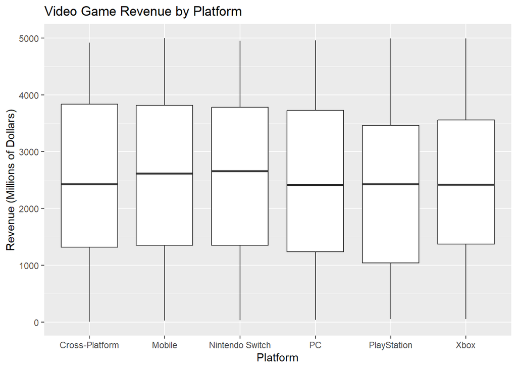

```r
# Boxplot of revenue by platform (in millions)
ggplot(gaming_clean, aes(x = Platform, y = Revenue_Millions)) +
  geom_boxplot() +
  labs(
    title = "Video Game Revenue by Platform",
    x = "Platform",
    y = "Revenue (Millions of Dollars)"
  )
```

Boxplot: Video Game Revenue by Platform

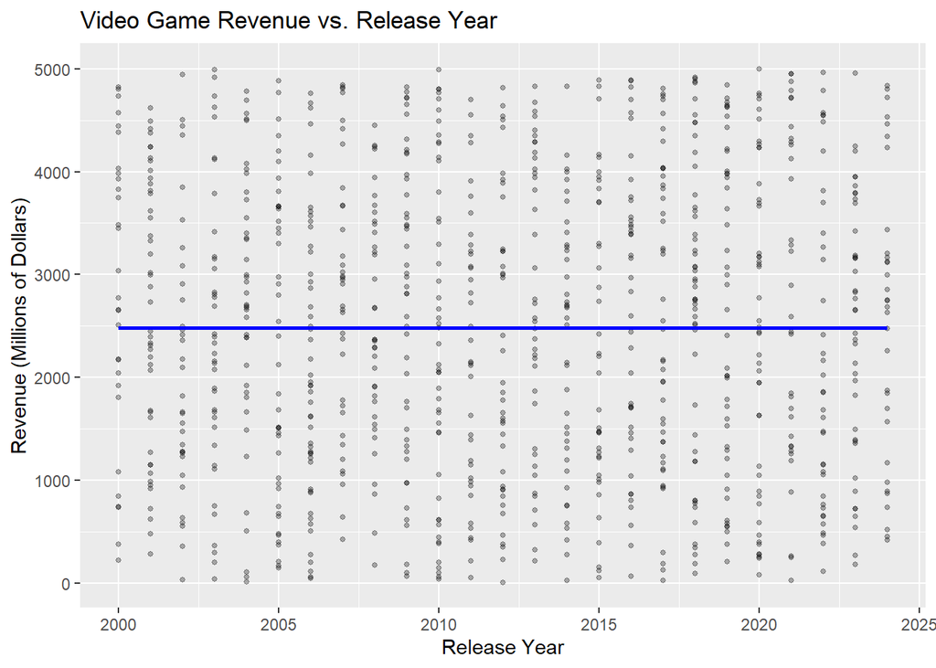

```r
# Scatterplot of revenue vs. release year (in millions)
ggplot(gaming_clean, aes(x = Release_Year, y = Revenue_Millions)) +
  geom_point(alpha = 0.3, size = 1) +
  geom_smooth(se = FALSE, color = "blue") +
  labs(
    title = "Video Game Revenue vs. Release Year",
    x = "Release Year",
    y = "Revenue (Millions of Dollars)"
  )
```

Scatterplot: Revenue vs. Release Year

The scatterplot displays the relationship between game release dates and their corresponding revenue values. The scatterplot contains game data points which follow a blue trend line. The blue trend line maintains a flat position which indicates no existing connection between release year and revenue. The release year of a game does not create a direct link to its revenue generation. The revenue values of games span across all release years without any specific pattern.

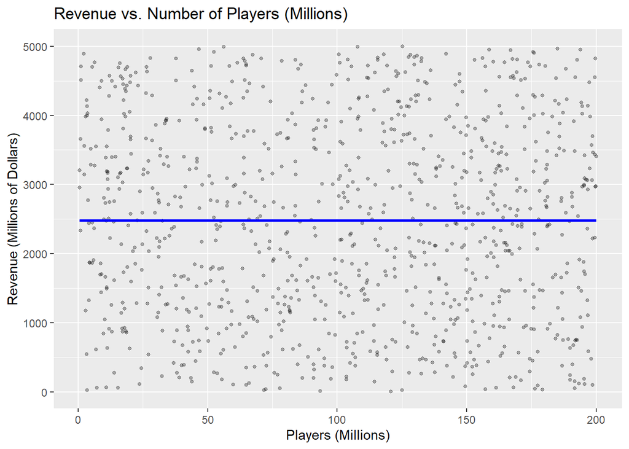

```r
# Scatterplot of revenue vs. players (both in millions)
ggplot(gaming_clean, aes(x = Players_Millions, y = Revenue_Millions)) +
  geom_point(alpha = 0.3, size = 1) +
  geom_smooth(se = FALSE, color = "blue") +
  labs(
    title = "Revenue vs. Number of Players (Millions)",
    x = "Players (Millions)",
    y = "Revenue (Millions of Dollars)"
  )
```

Scatterplot: Revenue vs. Number of Players

The scatterplot examines how revenue levels change when player numbers increase. The plot shows a wide distribution of points which contradicts the expected relationship between player numbers and revenue. The blue trend line maintains a flat position which indicates no existing relationship between player numbers and revenue. The data shows that games with large player bases can generate low revenue while games with smaller player bases can achieve higher revenue. The analysis indicates that player numbers do not effectively predict revenue levels in this particular dataset.

# 5 5. Visualization Quality and Storytelling

# 6 6. Modeling Approach

# 7 7. Model Implementation & Evaluation

# 8 8. Conclusions & Recommendations

# 9 9. Code Quality & Reproducibility

# 10 10. References

# 11 Appendix (Optional)